#### Project: C&SF:Flood Resiliency (Section 216) Study, FL

#### Risk Phase: Planning, Category: Communications

# Risk Summary: Study Delays - Stakeholders Acceptability

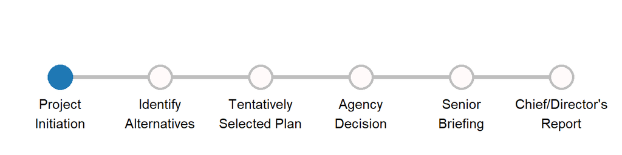

##### **Lead Discipline:** Project Management

##### Unacceptability of a study plan with stakeholders could delay study. There are multiple stakeholders within the study area, with different priorities in terms of what is more important to address in the region (e.g. flood risk, water quality risk, water supply risks, ecosystem restoration needs, quality of life, community development needs, and others), with different levels of understanding about feasibility of alternatives and overall purposes of the study. This could lead to different alternatives being selected by different stakeholder groups or complete non acceptance of an alternative; need of additional time and resources for enhancing and balancing alternatives.

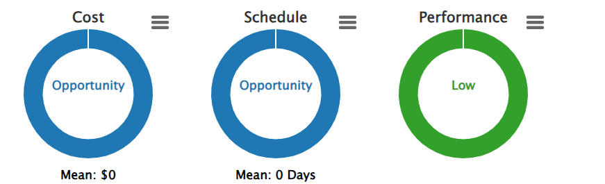

#### **Event Likelihood:**

#### As an example, the Miami Dade Back Bay Study proposed a plan during its previous study phase that consisted of constructing floodwalls within the urban setting and the plan was not accepted by stakeholders. LOSOM is another example as there are still discussions about balancing different stakeholders needs. Therefore, Project Manager and PDT is communicating early with stakeholders and getting feedback on each measure/ alternative being discussed.

#### **No Impact**

| Cost Impact | Schedule Impact | Performance Impact |
| --- | --- | --- |
| No Cost Impact anticipated. | No Schedule Impact is Anticipated | No Performance Impact is anticipated |

#### **Uniform Example**

| Cost Impact | Schedule Impact | Performance Impact |
| --- | --- | --- |
| *Lowest* $0 | *Lowest* 0 days | *Performance Impact:* Coordination with stakeholders could lead to an opportunity of building trust. |
| *Highest* $0 | *Highest* 0 days | *Performance Impact Type:* Other |
| Coordination with stakeholders | Approximate estimate for coordination needed through out the study. | Coordination with stakeholders could lead to an opportunity of building trust. |

[output not shown]

#### **Point Estimate Example**

[output not shown]

#### Risk Treatments:

Risk treatments have not been completed for this risk item

##### Risk Manager: Zulamet Vega-Liriano